# Exploratory Analaysis – Effect of Aggregation on Observations Study Results

12/xx/2018

# Data Preliminaries

Change generalizations to the correct path. Additionally, we clean up our data, removing rows where the confidence is NA, indicating responses where users chose not to include a generalization. We check the number of total insights, then look at the distribution of omitted generalizations.

```r
d <- read.csv("./data/[E1]Full-Cleaned-Main.tsv", sep="\t")
nrow(d)
```

```
## [1] 1941
```

```r
d$confidence <- suppressWarnings(as.numeric(as.character(paste(d$confidence))))
d$initSliderValue <- suppressWarnings(as.numeric(as.character(paste(d$initSliderValue))))
sapply(d, class)
```

```
##           assignmentId               workerId             confidence
##               "factor"               "factor"              "numeric"
##                     id        initSliderValue                  trial
##               "factor"              "numeric"              "integer"
##              datasetId                 specId               aggStrat
##              "integer"              "integer"               "factor"
##                correct quantitativePrediction   effectSizePrediction
##              "logical"              "logical"              "logical"
##               noEffect               isEffect           insightClass
##              "logical"              "logical"               "factor"
##                insight                   time
##               "factor"              "numeric"
```

```r
#double check to make sure we have the number of samples required by our power analysis (90 samples to reach at least 80% power)
unique(d$workerId)
```

```
##  [1] A0017268R9SKD8U2Y3F A100Y89FZO4J0B      A125KW9P18V5Z1
##  [4] A16KMPWYUZO0M6      A1835XBNR2UB4X      A196XR61DIW5GU
##  [7] A1AKX1C8GCVCTP      A1B76WYZ47BQJ       A1CH3TODZNQCES
## [10] A1DIGREVLNOXT3      A1DUPOUC9RNU4L      A1GXFMAC759VRM
## [13] A1JQ4KBFW7U3N1      A1PAY3X73PQ16S      A1PLB1NZOE2PQ7
## [16] A1PTH9KTRO06EG      A1Q5RFVJKMZBEN      A1QKIA8XRNEXIG
## [19] A1TMZLYXQAK8Q0      A1TP0SGMUSJ34B      A1UKAS30R0MFI6
## [22] A1VFRCYMWGWWCZ      A1WYDO7PQJ8UG       A1XTU3TVLXMKK1
## [25] A1Y55YV1WA1TTD      A204JAK7QRDWVM      A20SL254675EOK
## [28] A20SXG1DHDIDI7      A295P5SW3N83P6      A2AAY4VT9L71SY
## [31] A2ADEPVGNNXNPA      A2BRZKFG6WAVER      A2EI075XZT9Y2S
## [34] A2F9V69F6TZIAB      A2FLOH4DM8A4ZS      A2FLZP3C6U67JY
## [37] A2G7DTL156PTKA      A2G7N0X0PNX0EE      A2GB0RI43KU4Z
## [40] A2GZ00IMOT6L3X      A2M3KQ9CKP7YW       A2NZ7RMSBXESNI
## [43] A2OO4PG3LBLP5I      A2OVWCQ4B9AHFY      A2PXJTMWGUE5DC
```

[output cut: 16 more lines]

```r
#omit insights that were not decipherable
df <- subset(d, d$correct!="NA")
nrow(df) #1746
```

```
## [1] 1746
```

```r
#convert raw time into average time we can use
sum(is.na(df$time))
```

```
## [1] 380
```

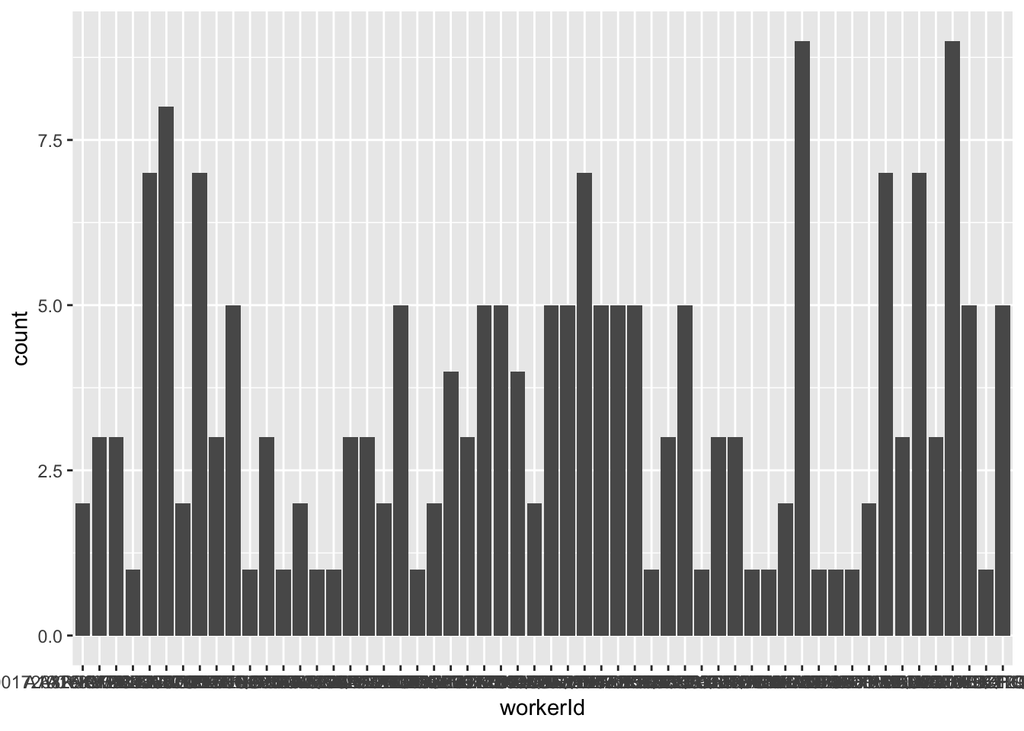

```r
#take out omitted subset and plot it
omits <- subset(d, is.na(d$correct))
#see how these were distributed across workers
p <- ggplot(omits, aes(x=workerId)) + geom_bar()
p
```

looks like we omitted a number of generalizations for some workers.

Next, we add a new column representing the aggregation strategy (agg | noagg | mean). We plot the general distribution of generalizations across generalization class. From the plot, participants made the most shape class generalizations with the noagg condition, the most agg with rank and the most mean with disagg + mean condition. Presumably since participants have to infer the mean given a no-aggregation visualization, they make more generalizations about the observed shape of the distribution. Similarly, since means are plotted, participants may be biased or primed to give some generalization about the mean. Additionally, there are very few variance generalizations, where a participant specifically mentioned the variance of a particular stimulus.

```r
# test <- d[d$workerId=="AZUHR4TGVXNN",]

df$aggStrat <- as.factor(ifelse(df$specId < 15, "agg", ifelse(df$specId >= 15 & df$specId < 30, "noagg", "mean")))

## Effect size estimates, where we remove the generalizations that reference null effects for the agg condition
df$isEffectRemoveNulls <- ifelse(df$effectSizePrediction==TRUE & (df$aggStrat!="agg") | df$isEffect==TRUE, TRUE, FALSE)

## Any effect size estimate, including all nulls for all aggregation conditions
df$isEffect <- df$effectSizePrediction

aggregationInsightClass <- ddply(df, c("aggStrat", "insightClass"), summarise,
                                 Correct=sum(correct==TRUE),
                                 Incorrect=sum(correct==FALSE),
                                 PercCorrect=Correct/(Incorrect+Correct),
                                 Total=Incorrect+Correct)
aggregationInsightClass
```

```
##    aggStrat      insightClass Correct Incorrect PercCorrect Total
## 1       agg       correlation      92        15   0.8598131   107
## 2       agg              mean     154        78   0.6637931   232
## 3       agg              rank      56        38   0.5957447    94
## 4       agg             shape      51        43   0.5425532    94
## 5       agg          variance       1         0   1.0000000     1
## 6      mean       correlation      76        20   0.7916667    96
## 7      mean              mean     173        66   0.7238494   239
## 8      mean misinterpretation       0         2   0.0000000     2
## 9      mean              rank      21        48   0.3043478    69
## 10     mean             shape     135        67   0.6683168   202
## 11     mean          variance       0         2   0.0000000     2
## 12    noagg       correlation      56        24   0.7000000    80
## 13    noagg              mean      99        53   0.6513158   152
## 14    noagg misinterpretation       0         1   0.0000000     1
## 15    noagg              rank      20        37   0.3508772    57
## 16    noagg             shape     223        94   0.7034700   317
## 17    noagg          variance       1         0   1.0000000     1
```

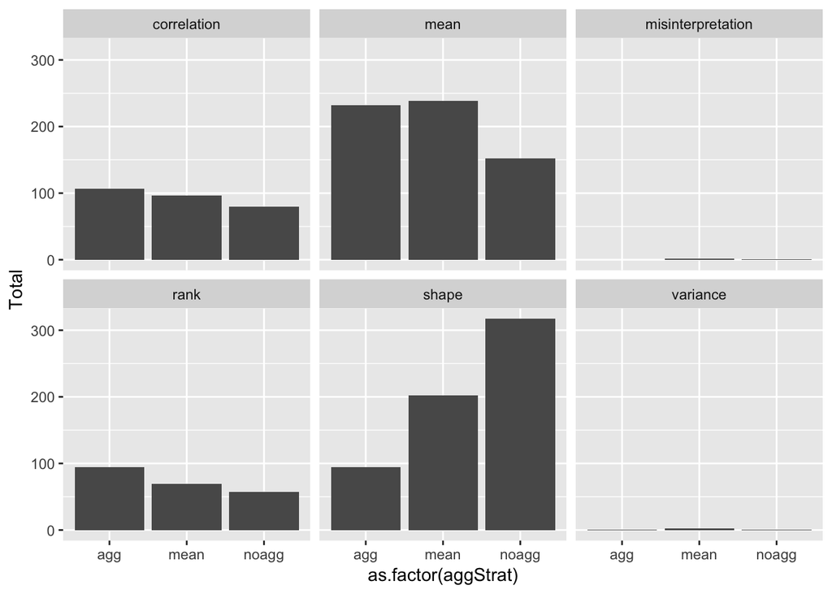

```r
p <- ggplot(aggregationInsightClass, aes(x=as.factor(aggStrat), y=Total)) + geom_bar(stat = "identity") + facet_wrap(~insightClass)
p
```

Now we look at number of instances of generalizations by spec ids to make sure all charts were shown as a sanity check. Since we don’t account for each unique account of trial, workerId and specId, it makes sense that some of the specIds are distributed unevenly.

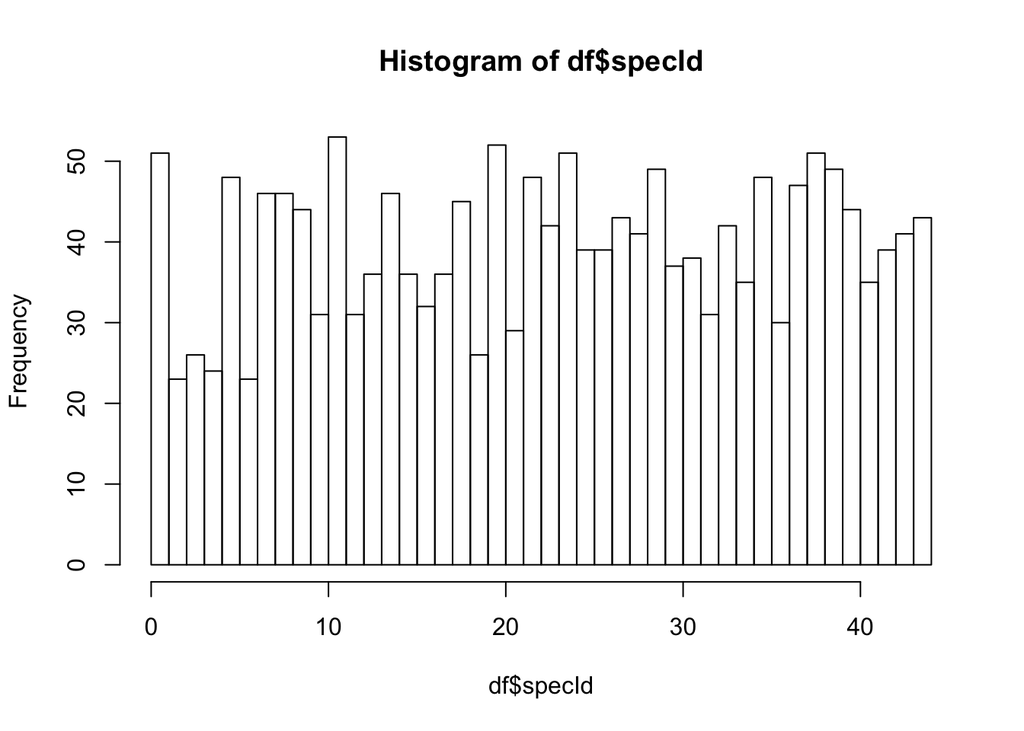

```r
#insightClassFactor <- as.factor(df$insightClass)
hist(df$specId, breaks=50)
```

# Generalization Number and Type Analysis

Let’s look at generalization count and class by aggregation strategy. Additionally, we facet by the generalization class so we can get a better break down of which are described more. We are curious if there is a learning effect after going through multiple trials. Judging from this plot, however, there doesn’t seem to be much of a pattern when looking at the trial number vs the aggregation strategy.

```r
#count (Each row is insight)
summary(df$aggStrat)
```

```
##   agg  mean noagg
##   528   610   608
```

```r
summary(df$insightClass)
```

```
##  misinterpretation        correlation               mean
##                  0                283                623
##  misinterpretation               rank              shape
##                  3                220                613
##           variance
##                  4
```

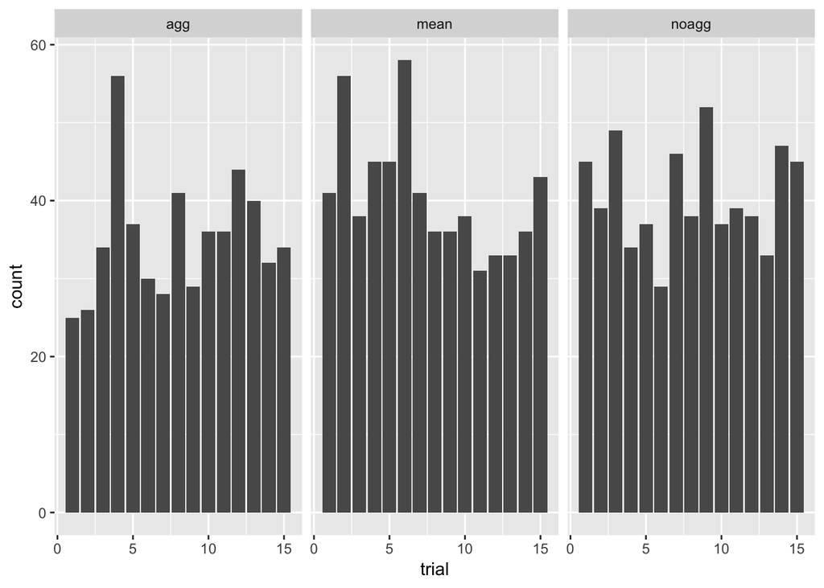

```r
# About same # of mean + shape, but much less

p <- ggplot(df, aes(x=trial)) + geom_bar() + facet_wrap(~aggStrat)
p
```

### Accuracy by Aggregation Strategy

We investigate the general numbers for correctness for each of our aggregation strategies to get a better sense of our data. Aggregate by default visualizations have a much lower rate of generalizations, but the percentage difference is quite small between the conditions.

```r
aggStratCorrect <- ddply(df, ~aggStrat, summarise, Correct=sum(correct==TRUE), Incorrect=sum(correct==FALSE), PercCorrect=Correct/(Incorrect+Correct), Total=Incorrect+Correct)
aggStratCorrect
```

```
##   aggStrat Correct Incorrect PercCorrect Total
## 1      agg     354       174   0.6704545   528
## 2     mean     405       205   0.6639344   610
## 3    noagg     399       209   0.6562500   608
```

```r
# Doesn't look like we see much different between visualization type. Will have to run a model to check if the different is significant at all
#   aggStrat Correct Incorrect PercCorrect Total
#      agg     354       174   0.6704545   528
#     mean     405       205   0.6639344   610
#    noagg     399       209   0.6562500   608
ddply(df, .(insightClass, aggStrat), summarise,
      Correct=sum(correct==TRUE),
      Incorrect=sum(correct==FALSE), PercCorrect=Correct/(Incorrect+Correct), Total=Incorrect+Correct, PercTotal=(Incorrect+Correct)/1746)
```

```
##         insightClass aggStrat Correct Incorrect PercCorrect Total
## 1        correlation      agg      92        15   0.8598131   107
## 2        correlation     mean      76        20   0.7916667    96
## 3        correlation    noagg      56        24   0.7000000    80
## 4               mean      agg     154        78   0.6637931   232
## 5               mean     mean     173        66   0.7238494   239
## 6               mean    noagg      99        53   0.6513158   152
## 7  misinterpretation     mean       0         2   0.0000000     2
## 8  misinterpretation    noagg       0         1   0.0000000     1
## 9               rank      agg      56        38   0.5957447    94
## 10              rank     mean      21        48   0.3043478    69
## 11              rank    noagg      20        37   0.3508772    57
## 12             shape      agg      51        43   0.5425532    94
## 13             shape     mean     135        67   0.6683168   202
## 14             shape    noagg     223        94   0.7034700   317
```

[output cut: 21 more lines]

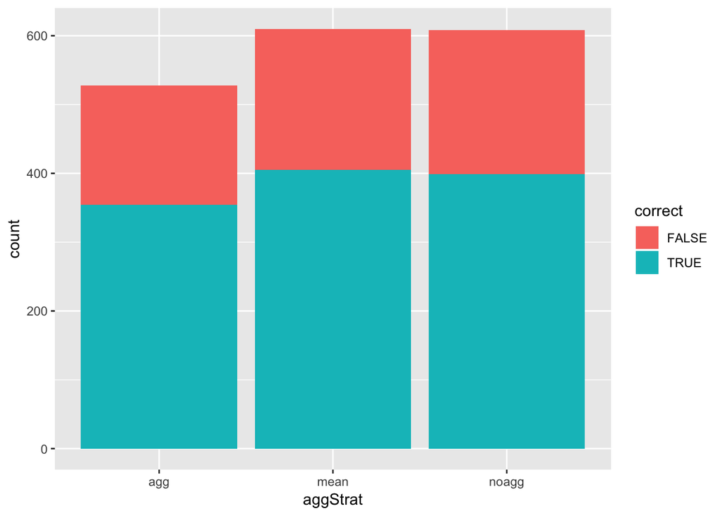

```r
p <- ggplot(df, aes(x=aggStrat)) + geom_bar(aes(fill=correct))
p
```

### Accuracy across aggregation strategy faceted by insight class

Next let’s take a look at the break down of insight class with respect to each insight class. We divde into 3 vectors, normalize them, and compare the values across aggregation strategy.

```r
# #means
# mean_insight <- ddply(df, .(insightClass, aggStrat), summarise, Correct=sum(correct==TRUE), Incorrect=sum(correct==FALSE), PercCorrect=Correct/(Incorrect+Correct), Total=Incorrect+Correct, PercTotal=(Incorrect+Correct)/610)
#
# mean_insight <-  mean_insight[mean_insight$aggStrat=="mean",]
#
# #noagg
# noagg_insight <- ddply(df, .(insightClass, aggStrat), summarise, Correct=sum(correct==TRUE), Incorrect=sum(correct==FALSE), PercCorrect=Correct/(Incorrect+Correct), Total=Incorrect+Correct, PercTotal=(Incorrect+Correct)/608)
# noagg_insight <-  noagg_insight[noagg_insight$aggStrat=="noagg",]
#
# #agg
# agg_insight <- ddply(df, .(insightClass, aggStrat), summarise, Correct=sum(correct==TRUE), Incorrect=sum(correct==FALSE), PercCorrect=Correct/(Incorrect+Correct), Total=Incorrect+Correct, PercTotal=(Incorrect+Correct)/528)
# agg_insight <-  agg_insight[agg_insight$aggStrat=="agg",]
#
# combined_insight_class <- rbind(mean_insight, noagg_insight, agg_insight)
# combined_insight_class

combined_insight_class <- suppressWarnings(
  ddply(df, .(aggStrat,insightClass), summarise,
        Correct=sum(correct==TRUE),
        Incorrect=sum(correct==FALSE),
        PercCorrect=Correct/(Incorrect+Correct),
        Total=Incorrect+Correct,
        PercTotal=(Incorrect+Correct)/sum(df$aggStrat == aggStrat)))
combined_insight_class
```

```
##    aggStrat      insightClass Correct Incorrect PercCorrect Total
## 1       agg       correlation      92        15   0.8598131   107
## 2       agg              mean     154        78   0.6637931   232
## 3       agg              rank      56        38   0.5957447    94
## 4       agg             shape      51        43   0.5425532    94
## 5       agg          variance       1         0   1.0000000     1
## 6      mean       correlation      76        20   0.7916667    96
## 7      mean              mean     173        66   0.7238494   239
## 8      mean misinterpretation       0         2   0.0000000     2
## 9      mean              rank      21        48   0.3043478    69
## 10     mean             shape     135        67   0.6683168   202
## 11     mean          variance       0         2   0.0000000     2
## 12    noagg       correlation      56        24   0.7000000    80
## 13    noagg              mean      99        53   0.6513158   152
## 14    noagg misinterpretation       0         1   0.0000000     1
```

[output cut: 21 more lines]

```r
percentTotal_class_agg <- ddply(combined_insight_class, .(aggStrat, insightClass), summarise, PercTotal=PercTotal)
percentTotal_class_agg
```

```
##    aggStrat      insightClass   PercTotal
## 1       agg       correlation 0.202651515
## 2       agg              mean 0.439393939
## 3       agg              rank 0.178030303
## 4       agg             shape 0.178030303
## 5       agg          variance 0.001893939
## 6      mean       correlation 0.157377049
## 7      mean              mean 0.391803279
## 8      mean misinterpretation 0.003278689
## 9      mean              rank 0.113114754
## 10     mean             shape 0.331147541
## 11     mean          variance 0.003278689
## 12    noagg       correlation 0.131578947
## 13    noagg              mean 0.250000000
## 14    noagg misinterpretation 0.001644737
## 15    noagg              rank 0.093750000
## 16    noagg             shape 0.521381579
## 17    noagg          variance 0.001644737
```

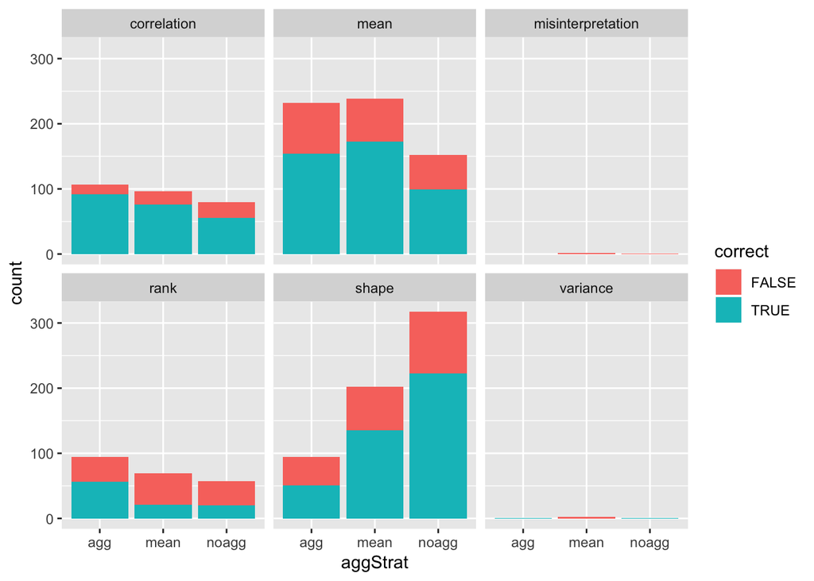

```r
# agg  - corr 20.3, mean 43.9, rank 17.8, shape 17.8, variance 0.2
# mean - corr 15.7, mean 39.2, rank 11.3, shape 33.1, variance 0.3
# disag- corr 13.2, mean 25.0, rank 9.4, shape 52.2, variance 0.2

#make this into a stacked bar chart w facet grid on insightClass
p <- ggplot(df, aes(x=aggStrat)) + geom_bar(aes(fill=correct)) + facet_wrap(~insightClass)
p
```

```r
#class
#p <- ggplot(df, aes(x=as.factor(insightClass))) + geom_bar() + facet_wrap(~aggStrat)
#p
```

### Basic effect size and quantitative estimate summary

Now let’s look at the two new codes for effectSize estimate and quantitative estimate First let’s add a new code that is anyEffectSize, which counts quantitative estimate or text effect size estimate

```r
df$anyEffectSize <- ifelse(df$quantitativePrediction==TRUE | df$effectSizePrediction==TRUE, TRUE, FALSE)
```

Let’s see how these are distributed across workers and aggregation strategy. There is a much lower percentage of effect size predictions for the noagg aggregation strategy.

```r
# how different are things by worker
# subset to only effectSizePrediction == TRUE
df_aes <- subset(df, df$anyEffectSize==TRUE)
nrow(df_aes) ## 1179
```

```
## [1] 1179
```

```r
df_es <- subset(df, df$effectSizePrediction==TRUE)
nrow(df_es) #210
```

```
## [1] 210
```

```r
# now do the same but for quantitative prediction
df_qp <- subset(df, df$quantitativePrediction==TRUE)
nrow(df_qp) #991
```

```
## [1] 991
```

```r
# Look at the total number of effect size, quant. prediction and the num of effect size that describes a null effect.
ddply(df, ~aggStrat, summarise,
      es = sum(effectSizePrediction==TRUE, na.rm=TRUE),
      qp = sum(quantitativePrediction==TRUE, na.rm=TRUE),
      es_null = sum(effectSizePrediction==TRUE & noEffect==TRUE, na.rm=TRUE),
      total = sum(effectSizePrediction==TRUE | effectSizePrediction==FALSE, na.rm=TRUE),
      PercES = es/total,
      PercQP = qp/total,
      PercES_null = es_null/total,
      PercES_null_ofES = es_null/es)
```

```
##   aggStrat es  qp es_null total     PercES    PercQP PercES_null
## 1      agg 99 264      77   528 0.18750000 0.5000000  0.14583333
## 2     mean 72 353      45   609 0.11822660 0.5796388  0.07389163
## 3    noagg 39 374      21   608 0.06414474 0.6151316  0.03453947
##   PercES_null_ofES
## 1        0.7777778
## 2        0.6250000
## 3        0.5384615
```

Additionally, let’s look at the average confidence per effect size estimate and quantitative estimate. There tends to be a lower average confidence for noagg strategy when looking at ES predictions. Similarly, there is a smaller difference, but still a lower avg confidence for noagg for QP.

```r
ddply(df_es, ~aggStrat, summarise, total=sum(effectSizePrediction==TRUE), avgConfidence=sum(confidence)/total)
```

```
##   aggStrat total avgConfidence
## 1      agg    99      72.55556
## 2     mean    72      72.90278
## 3    noagg    39      59.41026
```

```r
ddply(df_qp, ~aggStrat, summarise, total=sum(quantitativePrediction==TRUE), avgConfidence=sum(confidence)/total)
```

```
##   aggStrat total avgConfidence
## 1      agg   264      71.26894
## 2     mean   353      70.12181
## 3    noagg   374      65.42513
```

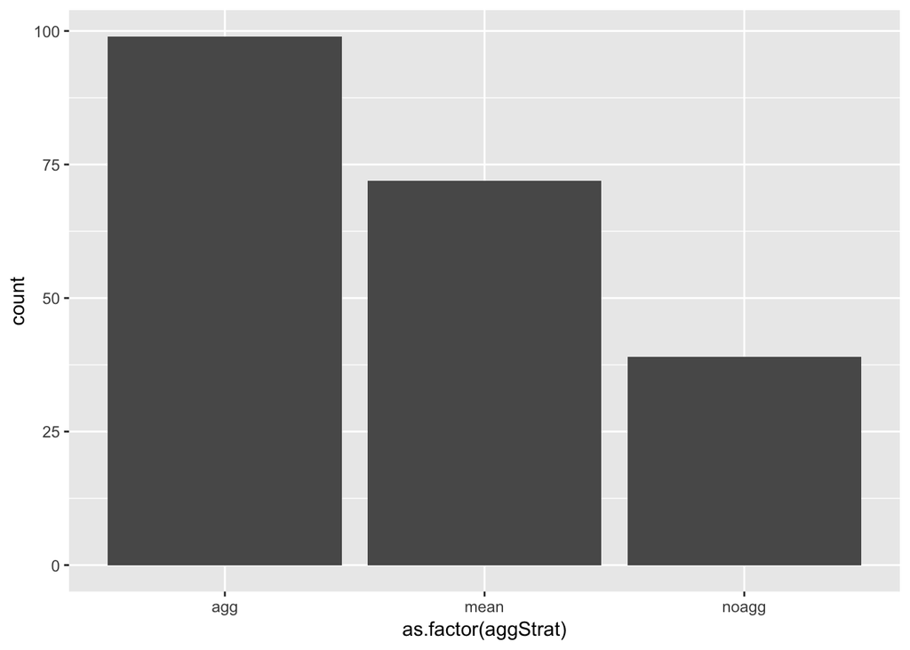

```r
p <- ggplot(df_es, aes(x=as.factor(aggStrat))) + geom_bar()
p
```

```r
#makes sense
#add correctness
#p <- ggplot(df_es, aes(x=as.factor(aggStrat))) + geom_bar() + facet_wrap(~correct)
#p
#p <- ggplot(df_qp, aes(x=as.factor(workerId))) + geom_bar()
#p

#p <- ggplot(df_qp, aes(x=as.factor(aggStrat))) + geom_bar()
#p
#add correctness
#p <- ggplot(df_qp, aes(x=as.factor(aggStrat))) + geom_bar() + facet_wrap(~correct)
#p
```

### Magnitude of effect size (none vs some effect)

Next, we’re interested in effect size estimates with and without the magnitude of effect size – when coding for ES observations, there were many that mentioned an effect of no magnitude, i.e. “Neither ad is more effective than the other.” What percentage of the ES are from this? What about when faceted by observation class?

```r
df_isEffect <- subset(df_es, df_es$isEffect==TRUE)

ddply(df_isEffect, .(aggStrat, insightClass), summarise,
      count=sum(isEffect==TRUE),
      total=sum(correct==TRUE)+sum(correct==FALSE),
      correct=sum(correct==TRUE),
      acc=correct/total)
```

```
##    aggStrat insightClass count total correct       acc
## 1       agg  correlation    53    53      47 0.8867925
## 2       agg         mean    34    34      27 0.7941176
## 3       agg         rank     4     4       0 0.0000000
## 4       agg        shape     7     7       5 0.7142857
## 5       agg     variance     1     1       1 1.0000000
## 6      mean  correlation    46    46      35 0.7608696
## 7      mean         mean    18    18      11 0.6111111
## 8      mean         rank     4     4       2 0.5000000
## 9      mean        shape     4     4       2 0.5000000
## 10    noagg  correlation    25    25      17 0.6800000
## 11    noagg         mean     7     7       5 0.7142857
## 12    noagg         rank     4     4       0 0.0000000
## 13    noagg        shape     3     3       3 1.0000000
```

```r
# 67 total observations from 210

p <- ggplot(df_isEffect, aes(x=aggStrat)) + geom_bar(aes(fill=correct))
p
```

[output not shown]

```r
p <- ggplot(df_isEffect, aes(x=aggStrat)) + geom_bar(aes(fill=correct)) + facet_wrap(~insightClass)
p
```

[output not shown]

### Magnitude of effect size, noagg considered

```r
df_isEffectIncludeNoagg <- subset(df_es, (df_es$noEffect==TRUE & (df_es$aggStrat=="noagg") | df_es$isEffect==TRUE))

ddply(df_isEffectIncludeNoagg, .(aggStrat), summarise, TotalIsEffect=sum(isEffect==TRUE), total=sum(correct==TRUE)+sum(correct==FALSE), correct=sum(correct==TRUE), acc=correct/total)
```

```
##   aggStrat TotalIsEffect total correct       acc
## 1      agg            99    99      80 0.8080808
## 2     mean            72    72      50 0.6944444
## 3    noagg            39    39      25 0.6410256
```

```r
ddply(df_isEffectIncludeNoagg, .(aggStrat, insightClass), summarise, count=sum(isEffect==TRUE), total=sum(correct==TRUE)+sum(correct==FALSE), correct=sum(correct==TRUE), acc=correct/total)
```

```
##    aggStrat insightClass count total correct       acc
## 1       agg  correlation    53    53      47 0.8867925
## 2       agg         mean    34    34      27 0.7941176
## 3       agg         rank     4     4       0 0.0000000
## 4       agg        shape     7     7       5 0.7142857
## 5       agg     variance     1     1       1 1.0000000
## 6      mean  correlation    46    46      35 0.7608696
## 7      mean         mean    18    18      11 0.6111111
## 8      mean         rank     4     4       2 0.5000000
## 9      mean        shape     4     4       2 0.5000000
## 10    noagg  correlation    25    25      17 0.6800000
## 11    noagg         mean     7     7       5 0.7142857
## 12    noagg         rank     4     4       0 0.0000000
## 13    noagg        shape     3     3       3 1.0000000
```

```r
# 88 of 210

p <- ggplot(df_isEffectIncludeNoagg, aes(x=aggStrat)) + geom_bar(aes(fill=correct))
p
```

[output not shown]

```r
p <- ggplot(df_isEffectIncludeNoagg, aes(x=aggStrat)) + geom_bar(aes(fill=correct)) + facet_wrap(~insightClass)
p
```

[output not shown]

Next, we calculate 95% confidence intervals based on accuracy per each participant, and plot the results.

```r
ddply(df_isEffectIncludeNoagg, .(workerId, aggStrat), summarise,
        TotalIsEffect=sum(isEffect==TRUE),
        total=sum(correct==TRUE)+sum(correct==FALSE),
        correct=sum(correct==TRUE),
        acc=correct/total
      ) %>%
  ddply(~aggStrat, summarise,
      N = sum((total)),
      meanAcc = mean(acc),
      sd = sd(acc),
      se = sd / sqrt(N)
    ) %>%
    {.} -> df_isEffect_FacetWorkerId_Stats

df_isEffect_FacetWorkerId_Stats
```

```
##   aggStrat  N   meanAcc        sd         se
## 1      agg 99 0.7830189 0.3637338 0.03655662
## 2     mean 72 0.6837607 0.4202388 0.04952562
## 3    noagg 39 0.6021505 0.4727332 0.07569790
```

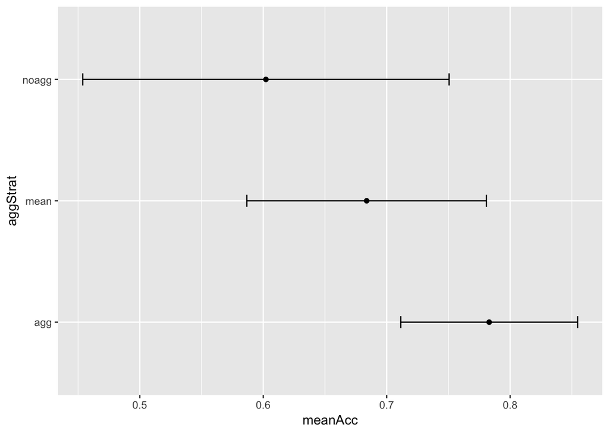

```r
pd <- position_dodge(0.1)
p <- ggplot(df_isEffect_FacetWorkerId_Stats, aes(y=meanAcc, x=aggStrat)) +
   geom_errorbar(aes(ymin=meanAcc-1.96*se, ymax=(meanAcc+1.96*se)), width=.1, position=pd) +
   geom_point() +
   coord_flip()
p
```

### Magnitude of effect size, noagg and mean considered

```r
df_isEffectIncludeNoaggMean <- subset(df_es, (df_es$noEffect==TRUE & (df_es$aggStrat=="noagg" | df_es$aggStrat=="mean") | df_es$isEffect==TRUE))

df_es$isEffectIncludeNulls <- ifelse(df_es$effectSizePrediction==TRUE & (df_es$aggStrat!="agg") | df_es$isEffect==TRUE, TRUE, FALSE)

ddply(df_isEffectIncludeNoaggMean, .(aggStrat), summarise, TotalIsEffect=sum(isEffect==TRUE), total=sum(correct==TRUE)+sum(correct==FALSE), correct=sum(correct==TRUE), acc=correct/total)
```

```
##   aggStrat TotalIsEffect total correct       acc
## 1      agg            99    99      80 0.8080808
## 2     mean            72    72      50 0.6944444
## 3    noagg            39    39      25 0.6410256
```

```r
ddply(df_isEffectIncludeNoaggMean, .(aggStrat, insightClass), summarise, count=sum(isEffect==TRUE), total=sum(correct==TRUE)+sum(correct==FALSE), correct=sum(correct==TRUE), acc=correct/total)
```

```
##    aggStrat insightClass count total correct       acc
## 1       agg  correlation    53    53      47 0.8867925
## 2       agg         mean    34    34      27 0.7941176
## 3       agg         rank     4     4       0 0.0000000
## 4       agg        shape     7     7       5 0.7142857
## 5       agg     variance     1     1       1 1.0000000
## 6      mean  correlation    46    46      35 0.7608696
## 7      mean         mean    18    18      11 0.6111111
## 8      mean         rank     4     4       2 0.5000000
## 9      mean        shape     4     4       2 0.5000000
## 10    noagg  correlation    25    25      17 0.6800000
## 11    noagg         mean     7     7       5 0.7142857
## 12    noagg         rank     4     4       0 0.0000000
## 13    noagg        shape     3     3       3 1.0000000
```

```r
# 88 of 210

p <- ggplot(df_isEffectIncludeNoaggMean, aes(x=aggStrat)) + geom_bar(aes(fill=correct))
p
```

[output not shown]

```r
p <- ggplot(df_isEffectIncludeNoaggMean, aes(x=aggStrat)) + geom_bar(aes(fill=correct)) + facet_wrap(~insightClass)
p
```

[output not shown]

```r
ddply(df_isEffectIncludeNoaggMean, .(workerId, aggStrat), summarise,
        TotalIsEffect=sum(isEffect==TRUE),
        total=sum(correct==TRUE)+sum(correct==FALSE),
        correct=sum(correct==TRUE),
        acc=correct/total
      ) %>%
  ddply(~aggStrat, summarise,
      N = sum((total)),
      meanAcc = mean(acc),
      sd = sd(acc),
      se = sd / sqrt(N)
    ) %>%
  {.} -> df_isEffect_FacetWorkerId_StatsMean

df_isEffect_FacetWorkerId_StatsMean
```

```
##   aggStrat  N   meanAcc        sd         se
## 1      agg 99 0.7830189 0.3637338 0.03655662
## 2     mean 72 0.6837607 0.4202388 0.04952562
## 3    noagg 39 0.6021505 0.4727332 0.07569790
```

```r
prop.test(x=c(8,50),
          n=c(22,72))
```

```
##
##  2-sample test for equality of proportions with continuity
##  correction
##
## data:  c(8, 50) out of c(22, 72)
## X-squared = 6.4666, df = 1, p-value = 0.01099
## alternative hypothesis: two.sided
## 95 percent confidence interval:
##  -0.58791594 -0.07370022
## sample estimates:
##    prop 1    prop 2
## 0.3636364 0.6944444
```

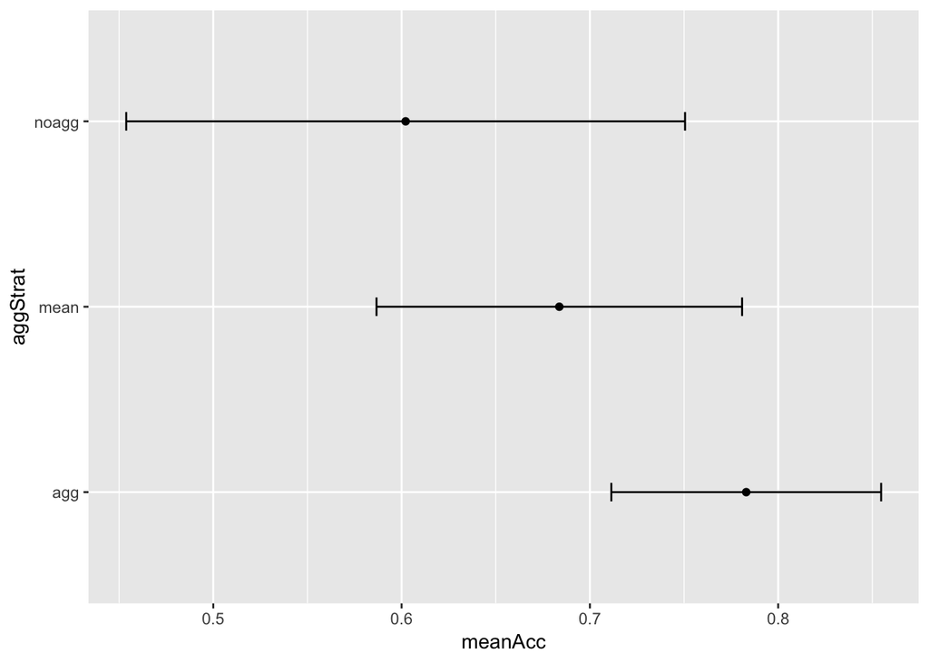

```r
df_isEffect_FacetWorkerId_StatsMean %>%
  ggplot(aes(y=meanAcc, x=aggStrat)) +
   geom_errorbar(aes(ymin=meanAcc-1.96*se, ymax=(meanAcc+1.96*se)), width=.1, position=position_dodge(0.1)) +
   geom_point() +
   coord_flip() %>%
  {.} -> p

p
```

# Embedded Ground Truth Accuracy

Next, we investigate that on a given trial, a participant saw a stimuli that had an embedded ground truth, and correctly identified it as such. Out of 45 total stimuli, 12 had ground truth embedded in them. We see that in the noagg aggregation strategy, correlation classed observations tend to be the most correct, perhaps due to the fact that people are seeing the entire distribution and can therefore more accuractely describe the effect size.

```r
gt_stimuli <- c(5, 8, 11, 14, 20, 23, 26, 29, 35, 38, 41, 44)
df_groundtruth <- subset(df, df$specId %in% gt_stimuli)
# 552 observations. More or less what we expect numerically (~a bit more than a quarter of 1746)

ddply(df_groundtruth, .(aggStrat, insightClass),
      summarise, total=sum(correct==TRUE)+sum(correct==FALSE),
      correct=sum(correct==TRUE),
      acc=correct/total)
```

```
##    aggStrat insightClass total correct       acc
## 1       agg  correlation    49      43 0.8775510
## 2       agg         mean    41      20 0.4878049
## 3       agg         rank    57      56 0.9824561
## 4       agg        shape    46      28 0.6086957
## 5      mean  correlation    46      44 0.9565217
## 6      mean         mean    49      35 0.7142857
## 7      mean         rank    34      20 0.5882353
## 8      mean        shape    48      20 0.4166667
## 9     noagg  correlation    40      36 0.9000000
## 10    noagg         mean    39      22 0.5641026
## 11    noagg         rank    26      14 0.5384615
## 12    noagg        shape    77      44 0.5714286
```

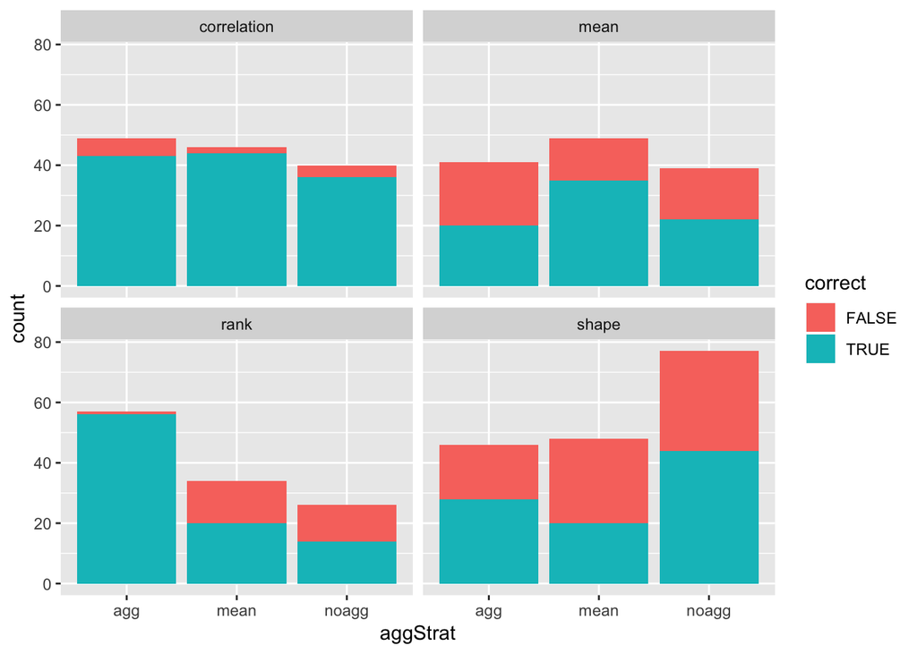

```r
p <- ggplot(df_groundtruth, aes(x=aggStrat)) + geom_bar(aes(fill=correct)) + facet_wrap(~insightClass)
p
```

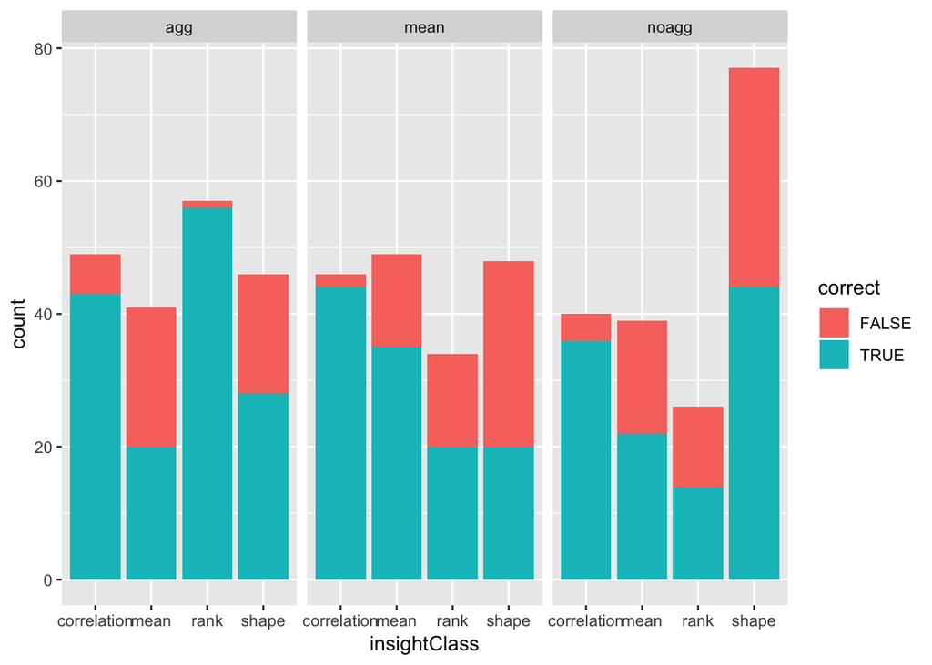

```r
p <- ggplot(df_groundtruth, aes(x=insightClass)) + geom_bar(aes(fill=correct)) + facet_wrap(~aggStrat)
p
```

Similarly, we are curious if when there is a ground truth, whether participants recorded an effect size in their observation. There’s so little data that it’s hard to glean anything from the plot generated.

```r
df_groundtruth_es <- subset(df_groundtruth, df_groundtruth$effectSizePrediction==TRUE)

ddply(df_groundtruth_es, .(aggStrat, insightClass), summarise,
      count=sum(isEffect==TRUE),
      total=sum(correct==TRUE)+sum(correct==FALSE),
      correct=sum(correct==TRUE),
      acc=correct/total)
```

```
##   aggStrat insightClass count total correct       acc
## 1      agg  correlation    12    12       8 0.6666667
## 2      agg         mean     2     2       2 1.0000000
## 3      agg        shape     1     1       1 1.0000000
## 4     mean  correlation     4     4       3 0.7500000
## 5     mean         rank     2     2       2 1.0000000
## 6    noagg  correlation     4     4       2 0.5000000
## 7    noagg         mean     1     1       1 1.0000000
## 8    noagg        shape     1     1       1 1.0000000
```

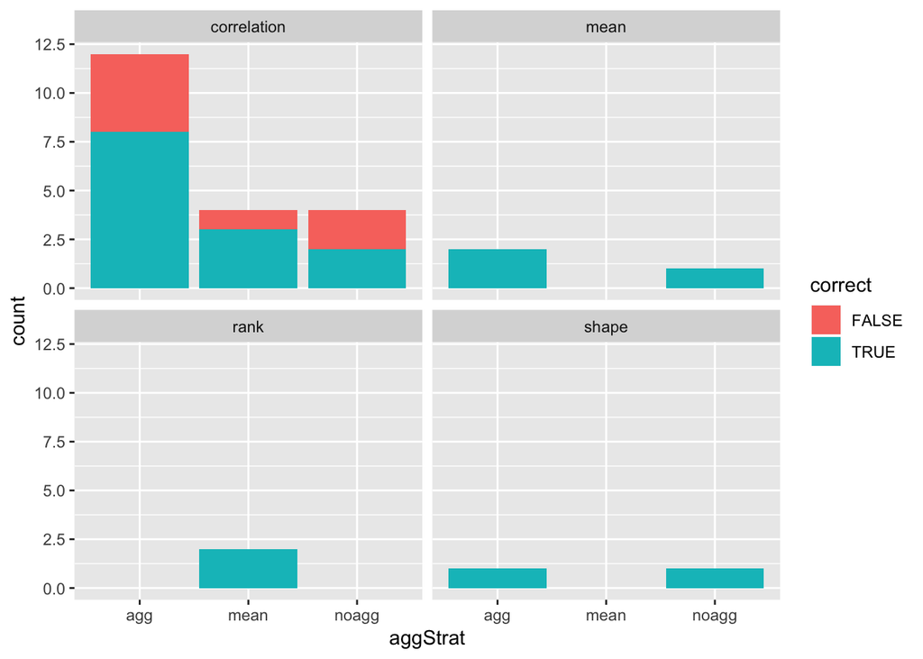

```r
p <- ggplot(df_groundtruth_es, aes(x=aggStrat)) + geom_bar(aes(fill=correct)) + facet_wrap(~insightClass)
p
```

# Confidence

Let’s take a look at distribution of confidence recorded by participants, There seems to be a lot of confidence values of 0.

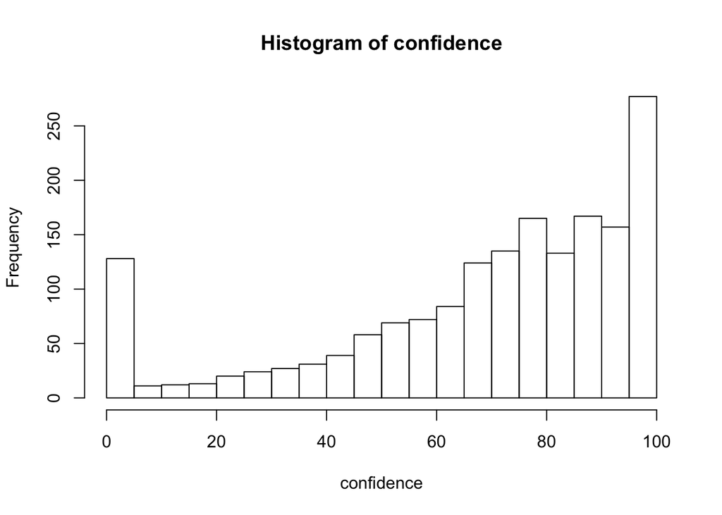

```r
confidence <- as.numeric(subset(df$confidence, as.numeric(df$confidence) >= 0))
hist(confidence, breaks=20)
```

```r
length(confidence[confidence>90]) #429 out of 1736 or 24.7\%
```

```
## [1] 434
```

```r
length(confidence)
```

```
## [1] 1746
```

```r
ddply(df, ~aggStrat, summarise, mean_conf=mean(confidence, na.rm=TRUE), sd_conf=sd(confidence, na.rm=TRUE))
```

```
##   aggStrat mean_conf  sd_conf
## 1      agg  71.97159 27.49492
## 2     mean  69.05410 28.85014
## 3    noagg  67.32566 28.31523
```

```r
df_agg <- subset(df, df$aggStrat=="agg")
df_noagg <- subset(df, df$aggStrat=="noagg")
df_mean <- subset(df, df$aggStrat=="mean")
```

Are there any relationships between the confidence and how correct a participant is?

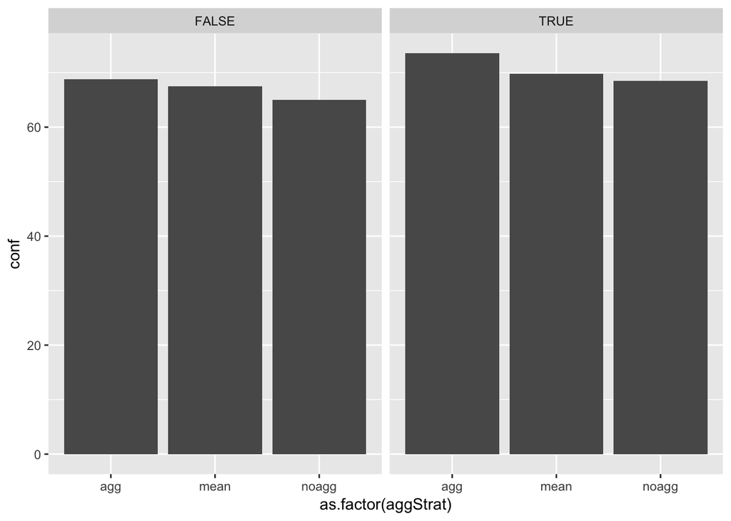

```r
conf_table2 <- ddply(df, c("aggStrat", "correct"), summarise, conf=mean(confidence, na.rm=TRUE))

p <- ggplot(conf_table2, aes(x=as.factor(aggStrat), y=conf)) + geom_col() + facet_wrap(~correct)
p
```

```r
df_c <- subset(df, df$correct==1)
df_i <- subset(df, df$correct==0)

ddply(df_c, ~aggStrat, summarise, conf_c=mean(confidence, na.rm=TRUE))
```

```
##   aggStrat   conf_c
## 1      agg 73.52260
## 2     mean 69.81975
## 3    noagg 68.52130
```

```r
ddply(df_i, ~aggStrat, summarise, conf_i=mean(confidence, na.rm=TRUE))
```

```
##   aggStrat   conf_i
## 1      agg 68.81609
## 2     mean 67.54146
## 3    noagg 65.04306
```

Could accuracy rates by aggregation strategy be confounded by different numbers of generalizations per aggregation strategy?

```r
ddply(df, ~aggStrat, summarise, Correct=sum(correct==TRUE), Incorrect=sum(correct==FALSE), Total=sum(Correct+Incorrect), PercCorrect=Correct/Total )
```

```
##   aggStrat Correct Incorrect Total PercCorrect
## 1      agg     354       174   528   0.6704545
## 2     mean     405       205   610   0.6639344
## 3    noagg     399       209   608   0.6562500
```

```r
#there are fewer agg insights - people are more cautious when they see no representation of uncertainty. Mean and agg are very similar on percent correct, but noagg is lower, perhaps because people do a lot of mean insights and noagg contributes extra judgment error bc they have to infer mean
```

Plot from above for context

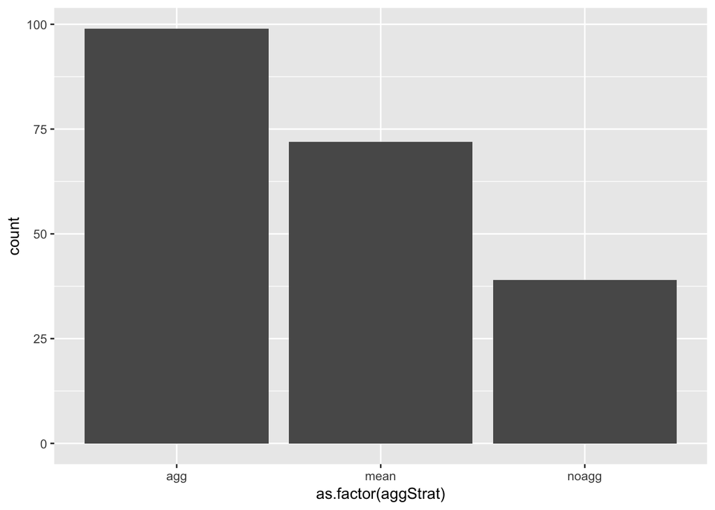

```r
p <- ggplot(df_es, aes(x=as.factor(aggStrat))) + geom_bar()
p
```

## Confidence by aggregation strategy

This only means so much when we look at the confidence of the entire dataset. Let’s now consider confidence with respect to each worker. We loop over all the workers, and find the biserial correlation, and average that across the dataset. We interpret when a worker gets all of their observations correct (biserial.cor gives NaN) as 0 correlation.

```r
library(ltm)
biserial.cor(df_agg$confidence, df_agg$correct, use = c("complete.obs"), level = 1)
```

```
## [1] -0.08053788
```

```r
biserial.cor(df_noagg$confidence, df_noagg$correct, use = c("complete.obs"), level = 1)
```

```
## [1] -0.05839196
```

```r
biserial.cor(df_mean$confidence, df_mean$correct, use = c("complete.obs"), level = 1)
```

```
## [1] -0.03733292
```

```r
# loop through each of our workers
df_worker_agg <- data.frame(conf=double(), biserial=double(), aggStrat=character(), workerId=character())
df_worker_noagg <- data.frame(conf=double(), biserial=double(), aggStrat=character(), workerId=character())
df_worker_mean <- data.frame(conf=double(), biserial=double(), aggStrat=character(), workerId=character())

for(workerId in unique(df$workerId)) {
   worker_agg <- df[df$aggStrat=="agg" & df$workerId==workerId,]
   worker_noagg <- df[df$aggStrat=="noagg" & df$workerId==workerId,]
   worker_mean <- df[df$aggStrat=="mean" & df$workerId==workerId,]

   if (nrow(worker_agg) > 0 ) {
      df_worker_agg <- rbind(df_worker_agg, data.frame(sum(worker_agg$confidence) / nrow(worker_agg),
                 biserial.cor(worker_agg$confidence, worker_agg$correct, use = c("complete.obs"), level = 1),
                 "agg",
                 workerId))
   }
   if (nrow(worker_noagg) > 0) {
      df_worker_noagg <- rbind(df_worker_noagg, data.frame(sum(worker_noagg$confidence) / nrow(worker_noagg),
                 biserial.cor(worker_noagg$confidence, worker_noagg$correct, use = c("complete.obs"), level = 1),
                 "noagg",
                 workerId))
      }
   if (nrow(worker_mean) > 0) {
      df_worker_mean <- rbind(df_worker_mean, data.frame(sum(worker_mean$confidence) / nrow(worker_mean),
                 biserial.cor(worker_mean$confidence, worker_mean$correct, use = c("complete.obs"), level = 1),
                 "mean",
                 workerId))
   }
}

## Change all of our NaN's to 0 correlation. These represent when a worker's observation for a given aggregation type
## is all marked as correct. Since there is no standard deviation, divide by zero error is introduced, giving NaN.

# helper function to check is.nan in data frames. from https://stackoverflow.com/questions/18142117/how-to-replace-nan-value-with-zero-in-a-huge-data-frame
is.nan.data.frame <- function(x)
do.call(cbind, lapply(x, is.nan))
#
df_worker_agg[is.nan(df_worker_agg)] <- 0
df_worker_noagg[is.nan(df_worker_noagg)] <- 0
df_worker_mean[is.nan(df_worker_mean)] <- 0

# Tidy up our column names
colnames(df_worker_agg) <- c("conf", "biserial", "aggStrat", "workerId")
colnames(df_worker_noagg) <- c("conf", "biserial", "aggStrat", "workerId")
colnames(df_worker_mean) <- c("conf", "biserial", "aggStrat", "workerId")

# Finally, concat all the different data frames together
# df_worker_CorConf <- rbind(data.frame(), df_worker_agg, df_worker_noagg, df_worker_mean)

df_worker_CorConf <- do.call("rbind", list(data.frame(), df_worker_agg, df_worker_noagg, df_worker_mean))

#do an analysis of average correlation/confidence but where you take into account the fact that workers may differ from one another
#loop through all workers
#group their confidence by aggregation strategy (3 dataframes with two cols, confidence and correct, each)
#find biserial cor for each group for that worker
#append the biserial cors to 3 arrays that record each individual worker cor for that aggreattion strategy.
#Finally, find the mean cor across all workers for each aggreation strategy and calculate a confidence interval on it (mean +/- 1.96 * sd)
```

The first plot we view is the number of sets of conditions removed by NaN to get a better sense of the data. It is hard to interpret this number, as a participant could have gotten all the generalizations correct or all incorrect given the aggregation type.

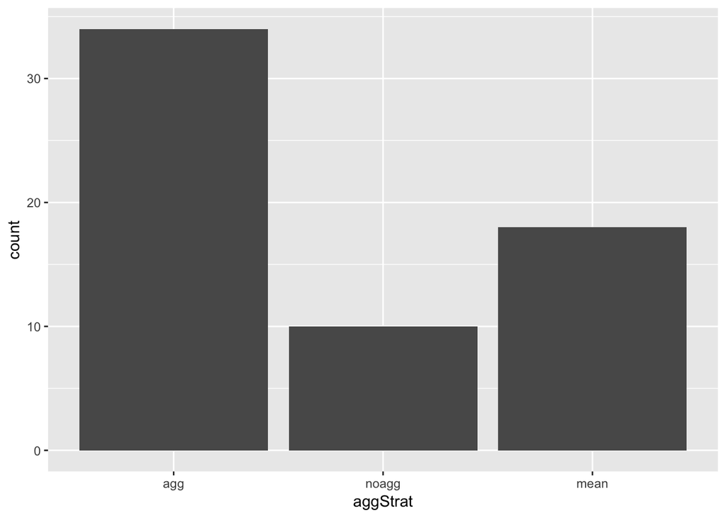

```r
# View number of instances where workers got a correlation of 0,
# or got the same correctness for all observations of a given agg strat
omits_CorConf <- df_worker_CorConf[df_worker_CorConf$biserial==0,]

p <- ggplot(omits_CorConf, aes(x=aggStrat)) + geom_bar()
p
```

Next, we view the general statistics for correlation when we take participant differences into account. There doesn’t to be a huge significant difference between average confidence and correlation.

```r
df_worker_avgCorConf <- ddply(df_worker_CorConf, ~aggStrat, summarize,
                              count=length(aggStrat),
                              avgConf=sum(conf) / length(aggStrat),
                              avgBiserial=sum(biserial)/length(aggStrat),
                              sdConf=sd(conf),
                              sdCorr=sd(biserial),
                              seCorr=sdConf/sqrt(length(aggStrat)),
                              seCorr=sdCorr/sqrt(length(aggStrat)))

df_worker_avgCorConf
```

```
##   aggStrat count  avgConf avgBiserial   sdConf    sdCorr   seCorr
## 1      agg    90 71.76873 -0.06478506 18.00758 0.4318808 1.898166
## 2    noagg    89 67.32606 -0.03030406 18.56376 0.4502757 1.967755
## 3     mean    90 68.50042 -0.03950103 20.03253 0.4966704 2.111614
```

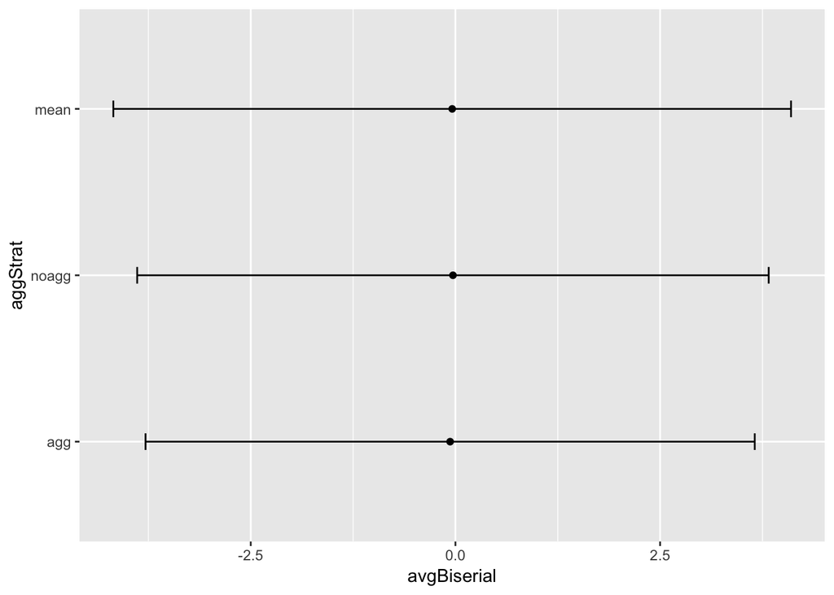

```r
# There doesn't seem to be a very significant difference between average confidence and the correlation...

# The errorbars overlapped, so use position_dodge to move them horizontally
pd <- position_dodge(0.1) # move them .05 to the left and right

p <- ggplot(df_worker_avgCorConf, aes(y=avgBiserial, x=aggStrat)) +
   geom_errorbar(aes(ymin=avgBiserial-1.96*seCorr, ymax=(avgBiserial+1.96*seCorr)), width=.1, position=pd) +
   geom_point() +
   coord_flip()
p
```

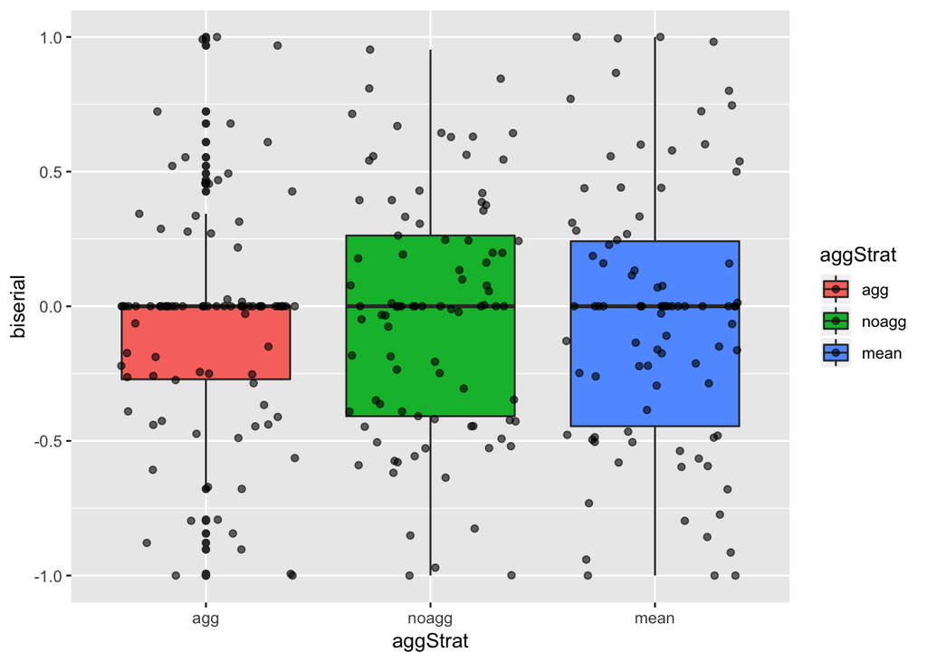

```r
## Next construct a box plot so we can see where everything lies
ggplot(df_worker_CorConf, mapping = aes(y=biserial, x=aggStrat, fill=aggStrat)) +
   geom_boxplot() +
  # geom_jitter(pch="-", size=4) +
   geom_jitter(alpha=0.6)
```

```r
   # stat_summary(fun.y=mean, geom="point", size=3) +
   # facet_grid(. ~ aggStrat)

## Let's do the same, but remove the biserial correlations of 0
df_withoutNoCorr <- ddply(df_worker_CorConf[df_worker_CorConf$biserial!=0,], ~aggStrat, summarize,
                          avgConf=sum(conf) / length(aggStrat),
                          avgBiserial=sum(biserial)/length(aggStrat),
                          sdConf=sd(conf),
                          sdCorr=sd(biserial),
                          seCorr=sdConf/sqrt(length(aggStrat)),
                          seCorr=sdCorr/sqrt(length(aggStrat)))

df_withoutNoCorr
```

```
##   aggStrat  avgConf avgBiserial   sdConf    sdCorr   seCorr
## 1      agg 69.74438 -0.10411885 18.50268 0.5455777 2.472524
## 2    noagg 66.29750 -0.03414001 18.83818 0.4781307 2.119460
## 3     mean 69.56184 -0.04937628 16.79929 0.5556311 1.979816
```

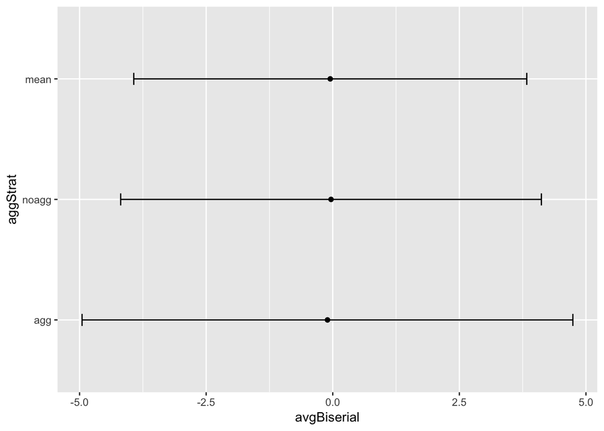

```r
p <- ggplot(df_withoutNoCorr, aes(y=avgBiserial, x=aggStrat)) +
   geom_errorbar(aes(ymin=avgBiserial-1.96*seCorr, ymax=(avgBiserial+1.96*seCorr)), width=.1, position=pd) +
   geom_point() +
   coord_flip()
p
```

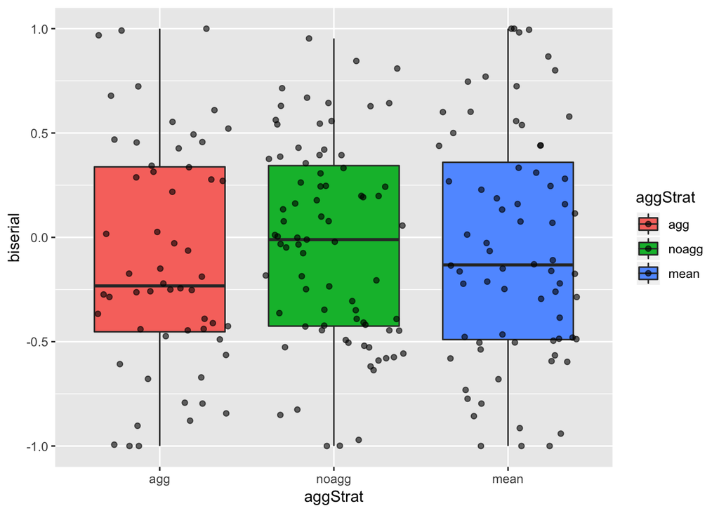

```r
## Similarly construct a box plot
ggplot(df_worker_CorConf[df_worker_CorConf$biserial!=0,], mapping = aes(y=biserial, x=aggStrat, fill=aggStrat)) +
   geom_boxplot() +
  # geom_jitter(pch="-", size=4) +
   geom_jitter(alpha=0.6)
```

### First Trial Confidence

Additionally, we will look at the first trial, when the idea of asking for confidence is first elicited to the worker. This might give us a better sense of how someone repsonds when first asked for confidence with regard to their answer.

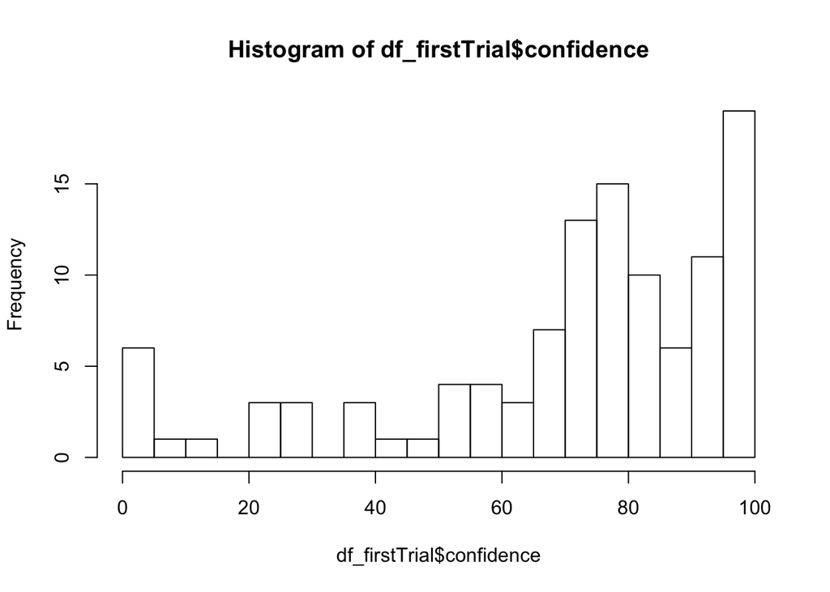

```r
#Also, do an analysis of first trial responses, where trial = 1.
#Look at the aggStrat distribution of first trial, confidence by aggStrat, QP/ES first trial
# subset data so you only look at first trial
df_firstTrial <- df[df$trial==1,]
# at first glance, the distribution of first trial confidence is similar to that of the entire set
hist(df_firstTrial$confidence, breaks=20)
```

Let’s look at the distribution across aggergation strategy and class. The distribution we get seems to be pretty similar to when we plot the distribution of all the data.

```r
summary(df_firstTrial$aggStrat)
```

```
##   agg  mean noagg
##    25    41    45
```

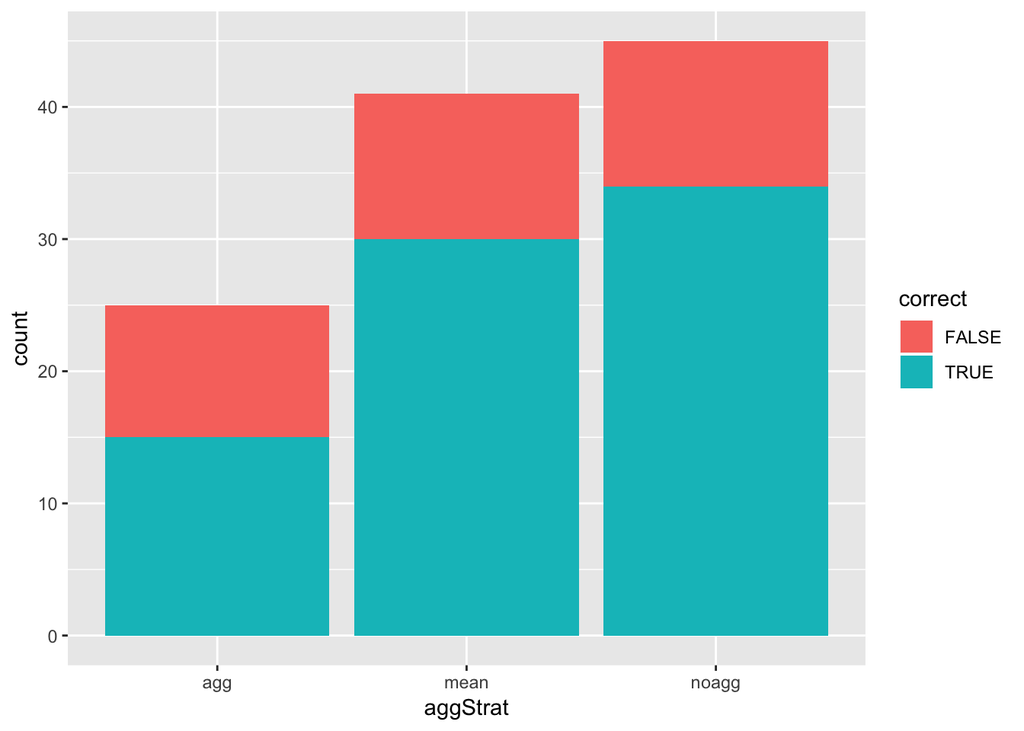

```r
# Here's the correctness faceted by the aggregation strategy
# There are the most amount of no aggregate generalizations.
p <- ggplot(df_firstTrial, aes(x=aggStrat)) + geom_bar(aes(fill=correct))
p
```

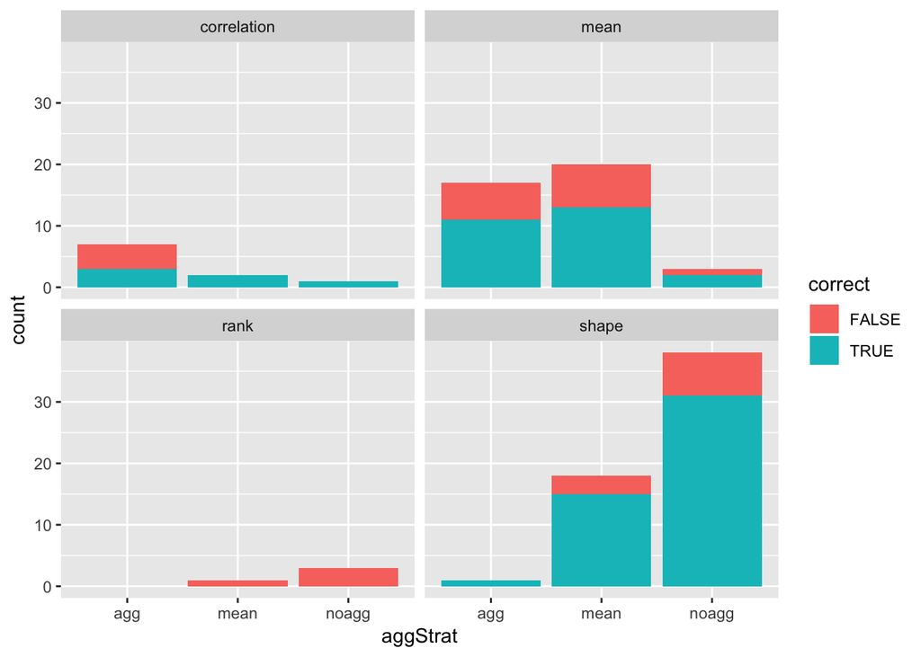

```r
# And now the same, except faceted by insight class. There aren't any variance generalizations on the first trial.
p <- ggplot(df_firstTrial, aes(x=aggStrat)) + geom_bar(aes(fill=correct)) + facet_wrap(~insightClass)
p
```

```r
# There are less generalizations on first trial for agg

# Look at correctness for first trial
ddply(df_firstTrial, ~aggStrat, summarise,
      Correct=sum(correct==TRUE),
      Incorrect=sum(correct==FALSE),
      PercCorrect=Correct/(Incorrect+Correct),
      Total=Incorrect+Correct)
```

```
##   aggStrat Correct Incorrect PercCorrect Total
## 1      agg      15        10   0.6000000    25
## 2     mean      30        11   0.7317073    41
## 3    noagg      34        11   0.7555556    45
```

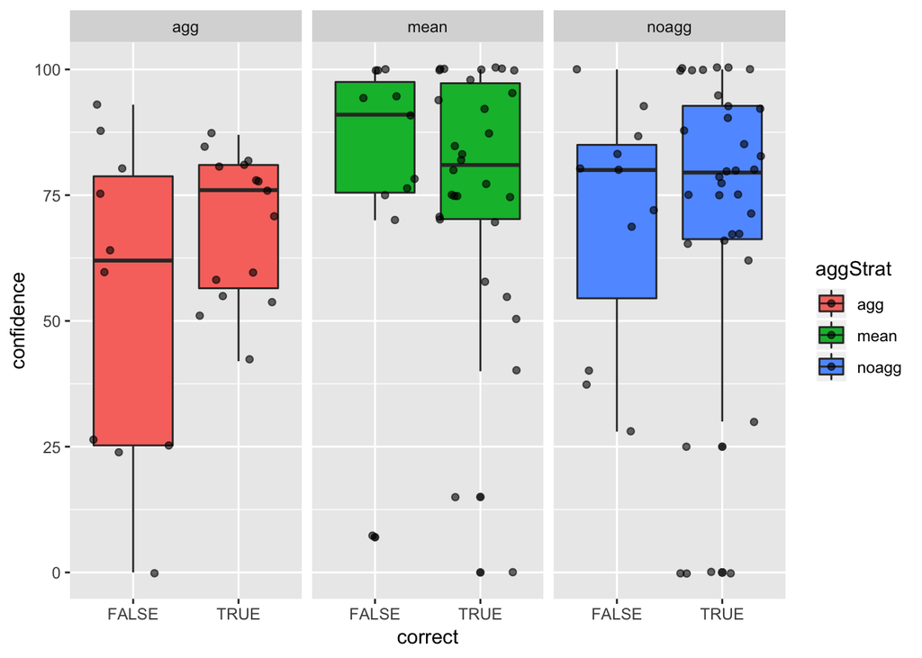

```r
ggplot(df_firstTrial, mapping = aes(y=confidence, x=correct, fill=aggStrat)) +
   geom_boxplot() +
   geom_jitter(alpha=0.6) +
   facet_wrap(~aggStrat)
```

For the first trial alone, there seem to be a greater difference of correctness percentage. All 3 aggregation strategies hovered around 65-70% accurate for all trials, and here, agg does worse by a decent margin — 60% compared to 75.5% for dis-aggregated.

#### First Trial Confidence faceted by workerId

When we take into account workers, we find that only 80/90 participants gave us observations on the first trial, even though there are a total of 111 observations. We find that the aggregation strategy accuracy rating changes slightly, but agg still does the worst: 60.4% foragg compared to 69.6% for mean and 73.8% for noagg.

We calculate the se and plot the values below.

```r
# Interesting... gives us 80 observations, since 10 participants didn't make observations ont the first trial
df_firstTrial_facetWorker <- ddply(df_firstTrial, .(aggStrat, workerId), summarise, Correct=sum(correct==TRUE), Incorrect=sum(correct==FALSE), PercCorrect=Correct/(Incorrect+Correct), Total=Incorrect+Correct)

df_firstTrial_facetWorker_stats <- ddply(df_firstTrial_facetWorker, ~aggStrat, summarise,
        N = sum((Total)),
        meanAcc = mean(PercCorrect),
        sd = sd(PercCorrect),
        se = sd / sqrt(N)
      )

df_firstTrial_facetWorker_stats
```

```
##   aggStrat  N   meanAcc        sd         se
## 1      agg 25 0.6041667 0.4885464 0.09770927
## 2     mean 41 0.6964286 0.4582431 0.07156555
## 3    noagg 45 0.7380952 0.4112076 0.06129921
```

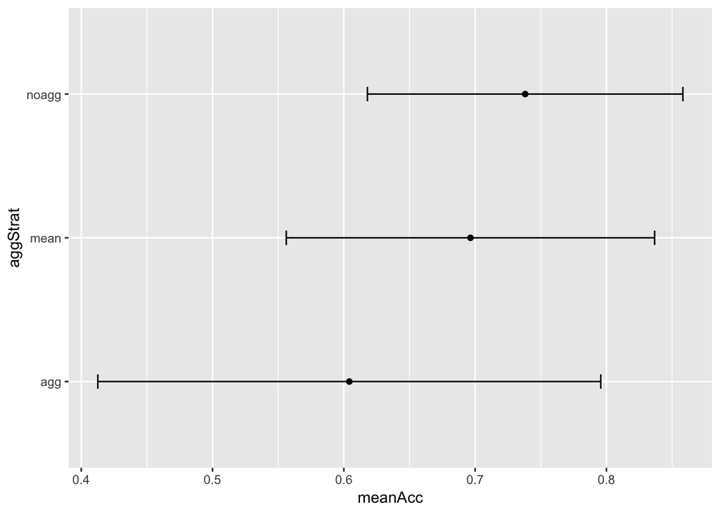

```r
# aggStrat  N    mean         sd          se
# agg         25      0.6041667   0.4885464   0.09770927
# mean      41    0.6964286   0.4582431   0.07156555
# noagg     45    0.7380952   0.4112076   0.06129921

pd <- position_dodge(0.1)
p <- ggplot(df_firstTrial_facetWorker_stats, aes(y=meanAcc, x=aggStrat)) +
   geom_errorbar(aes(ymin=meanAcc-1.96*se, ymax=(meanAcc+1.96*se)), width=.1, position=pd) +
   geom_point() +
   coord_flip()
p
```

Now, lets take a quick look at the QP/ES/ES null descriptive statistics.

```r
# Look at df_firstTrial$aggStrat, df_firstTrial$confidence, df_firstTrial$correct
# df_firstTrial$quantitativePrediction, df_firstTrial$effectSizePrediction, etc.

ddply(df_firstTrial, ~aggStrat, summarise,
      es=sum(effectSizePrediction==TRUE, na.rm=TRUE),
      qp=sum(quantitativePrediction==TRUE, na.rm=TRUE),
      es_null=sum(effectSizePrediction==TRUE & noEffect==TRUE, na.rm=TRUE),
      total=sum(effectSizePrediction==TRUE | effectSizePrediction==FALSE, na.rm=TRUE),
      PercES=es/total,
      PercQP=qp/total,
      PercES_null=es_null/total)
```

```
##   aggStrat es qp es_null total     PercES    PercQP PercES_null
## 1      agg 10 11       4    25 0.40000000 0.4400000  0.16000000
## 2     mean  7 27       4    41 0.17073171 0.6585366  0.09756098
## 3    noagg  2 34       1    45 0.04444444 0.7555556  0.02222222
```

# Bayesian models

```r
library(rethinking)
#data prep
myvars <- c("workerId", "aggStrat", "specId", "correct", "trial", "effectSizePrediction", "quantitativePrediction", "confidence", "datasetId")
dstan <- df[myvars]
dstan$aggr <- ifelse(dstan$aggStrat=="agg", 1, 0)
dstan$mmean <- ifelse(dstan$aggStrat=="mean", 1, 0)
dstan$noaggr <- ifelse(dstan$aggStrat=="noagg", 1, 0)
dstan$worker_id <- as.integer(as.factor(dstan$workerId))

summary(dstan$worker_id)
```

```
##    Min. 1st Qu.  Median    Mean 3rd Qu.    Max.
##    1.00   23.00   46.00   46.07   69.00   90.00
```

```r
#ifelse(dstan$effectSizePrediction=="TRUE?", "TRUE", "NA")

#for (i in 1:nrow(dstan)){
#  if(dstan$worker_id[i] >= 49) {
#    dstan$worker_id[i] <- dstan$worker_id[i]-1
#  }
#}

#dstan$worker_id <- as.integer(dstan$worker_id)
dstan$spec_ID <- dstan$specId + 1

dstan$spec_id <- dstan$datasetId
summary(dstan$spec_id)
```

```
##    Min. 1st Qu.  Median    Mean 3rd Qu.    Max.
##   1.000   5.000   9.000   8.412  12.000  15.000
```

```r
dstan$spec_id <- as.integer(paste(dstan$spec_id))
summary(dstan$spec_id)
```

```
##    Min. 1st Qu.  Median    Mean 3rd Qu.    Max.
##   1.000   5.000   9.000   8.412  12.000  15.000
```

Create a plotting function so that we can view our models as violin plots.

```r
#plotting code
plot_model_mu_coefs = function(m) {

   #only keep the following columns since we don't want each
   keep <- c("a", "btrial", "bnoagg", "bmean", "sigma_spec", "sigma_worker")
   #m_v_interc_specId

  mu_coefs <- m %>%
    extract.samples() %>%  #only want intercept, btrial, bnoagg, bmean, sigma spec, sigma worker, each of these is a column
    as.data.frame() #%>%

  # mu_coefs[ , !names(mu_coefs) %in% remove]
   # transmute(
  #    intercept = Intercept,
     # discrete = mu_bd,
    #  predict = mu_bp,
    #  `discrete*predict` = mu_bdp,
    #  rules = mu_br,
  #    trial = trial
   # ) #%>%


   mu_coefs_plot <- gather(data=mu_coefs[keep], key=item, value=value)
   mu_coefs_plot %>%
      ggplot(aes(x = reorder(item, desc(item)), y = value)) +
      geom_violin(fill = "black", color = NA) +
      theme(axis.text=element_text(size=18),
         panel.grid.major = element_blank(), panel.grid.minor = element_blank(),
         panel.background = element_rect(fill = "white", color="grey50")) +
      labs(x = "Coefficients (mu)", y = "") + coord_flip()
}
```

## Accuracy Model

```r
set.seed(127)  #mean 0.89 starts at 0.02
m_v_interc_specId <- map2stan(
  alist(
    correct ~ dbinom(1, p) ,
    logit(p) <- a + a_worker[worker_id] + a_spec[spec_ID] + btrial * trial + bnoagg*noaggr + bmean*mmean,
    a_worker[worker_id] ~ dnorm(0, sigma_worker),
    a_spec[spec_ID] ~ dnorm(0, sigma_spec),
    c(a, bnoagg, bmean, btrial) ~ dnorm(0, 10),
    c(sigma_worker, sigma_spec) ~ dcauchy(0, 1)
  ),
  data=dstan , warmup=1000 , iter=5000 , chains=1 , cores=3)
```

```
## Computing WAIC
```

```
## Constructing posterior predictions
```

```
## [ 400 / 4000 ]
[ 800 / 4000 ]
[ 1200 / 4000 ]
[ 1600 / 4000 ]
[ 2000 / 4000 ]
[ 2400 / 4000 ]
[ 2800 / 4000 ]
[ 3200 / 4000 ]
[ 3600 / 4000 ]
[ 4000 / 4000 ]
```

```r
##
precis(m_v_interc_specId, depth = 2, prob=0.95)
```

```
##               Mean StdDev lower 0.95 upper 0.95 n_eff Rhat
## a_worker[1]  -0.52   0.36      -1.20       0.18  5139    1
## a_worker[2]  -0.24   0.46      -1.16       0.64  5830    1
## a_worker[3]   0.70   0.51      -0.30       1.68  6043    1
## a_worker[4]  -0.57   0.39      -1.31       0.21  5290    1
## a_worker[5]  -0.68   0.54      -1.75       0.37  7519    1
## a_worker[6]  -1.15   0.48      -2.08      -0.20  5296    1
## a_worker[7]   0.40   0.59      -0.79       1.48  7462    1
## a_worker[8]  -0.31   0.51      -1.32       0.69  7603    1
## a_worker[9]  -0.19   0.58      -1.32       0.94  9289    1
## a_worker[10]  0.84   0.56      -0.25       1.94  6405    1
## a_worker[11] -0.32   0.53      -1.35       0.74  7552    1
## a_worker[12]  0.24   0.46      -0.67       1.16  6317    1
## a_worker[13]  0.29   0.49      -0.69       1.22  6229    1
## a_worker[14] -0.91   0.50      -1.88       0.10  6364    1
## a_worker[15]  0.34   0.54      -0.65       1.45  6465    1
## a_worker[16]  0.52   0.51      -0.50       1.46  7175    1
## a_worker[17]  0.25   0.43      -0.59       1.11  6974    1
## a_worker[18] -0.28   0.44      -1.17       0.54  6232    1
## a_worker[19]  0.66   0.44      -0.20       1.53  5394    1
## a_worker[20] -1.34   0.48      -2.30      -0.39  4556    1
## a_worker[21]  0.36   0.39      -0.37       1.14  4467    1
## a_worker[22] -0.62   0.41      -1.46       0.13  5299    1
## a_worker[23]  1.77   0.55       0.73       2.85  4046    1
## a_worker[24] -0.05   0.48      -1.05       0.85  8176    1
## a_worker[25]  0.66   0.55      -0.44       1.71  6437    1
## a_worker[26] -0.38   0.42      -1.22       0.43  6017    1
## a_worker[27] -0.52   0.52      -1.57       0.46  7871    1
## a_worker[28]  0.78   0.58      -0.34       1.93  6074    1
## a_worker[29] -0.57   0.49      -1.50       0.39  6389    1
## a_worker[30]  0.16   0.40      -0.62       0.92  5338    1
## a_worker[31]  0.69   0.61      -0.49       1.84  6588    1
## a_worker[32] -0.02   0.50      -0.97       1.02  7059    1
## a_worker[33]  0.18   0.50      -0.79       1.16  6972    1
## a_worker[34]  0.26   0.53      -0.82       1.25  7312    1
## a_worker[35]  0.32   0.52      -0.65       1.35  8030    1
## a_worker[36]  0.32   0.49      -0.61       1.28  7638    1
## a_worker[37]  0.01   0.51      -0.93       1.03  5376    1
## a_worker[38]  0.57   0.48      -0.34       1.53  6446    1
## a_worker[39]  1.13   0.63      -0.11       2.37  5878    1
```

[output cut: 87 more lines]

```
## a_spec[37]    0.88   0.55      -0.15       1.97  2307    1
## a_spec[38]    0.50   0.54      -0.46       1.64  2273    1
## a_spec[39]    0.11   0.49      -0.83       1.08  1721    1
## a_spec[40]    1.10   0.55       0.09       2.20  2226    1
## a_spec[41]   -0.47   0.54      -1.42       0.67  1495    1
## a_spec[42]    1.37   0.59       0.21       2.52  1621    1
## a_spec[43]   -0.23   0.56      -1.39       0.80  1432    1
## a_spec[44]   -2.07   0.49      -3.08      -1.17  1249    1
## a_spec[45]    0.51   0.51      -0.46       1.52  1218    1
## a             0.75   0.40      -0.05       1.51   749    1
## bnoagg       -0.02   0.50      -1.02       0.94   666    1
## bmean         0.03   0.51      -1.04       0.96   813    1
## btrial        0.04   0.02       0.01       0.06  6477    1
## sigma_worker  0.77   0.10       0.57       0.96  1396    1
## sigma_spec    1.25   0.16       0.97       1.59  3033    1
```

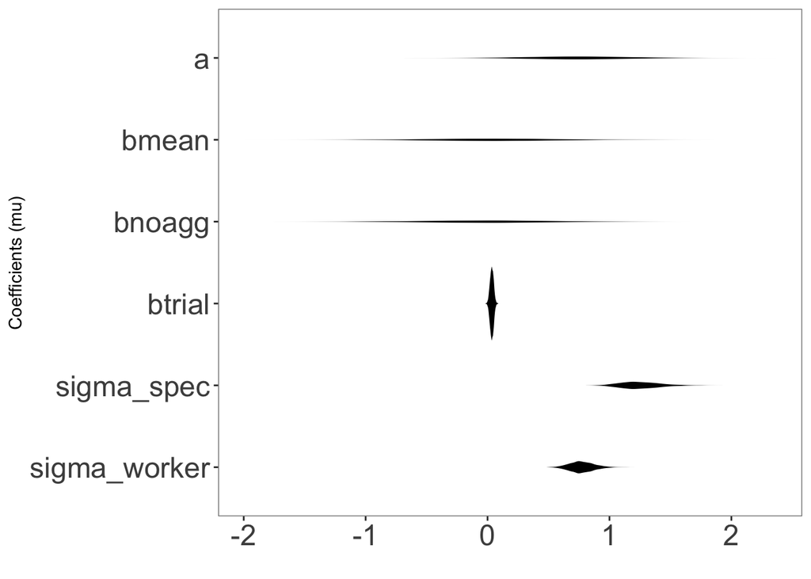

```r
# svg(file="acc_model.svg", width=600, height=300)
# plot(precis(m_v_interc_specId, prob=0.95))
# dev.off()

#              Mean     StdDev lower 0.95 upper 0.95 n_eff Rhat
# a             0.76   0.37       0.08       1.49   918    1
# bnoagg       -0.04   0.49      -0.97       0.97   857    1
# bmean         0.05   0.49      -0.87       1.08   706    1
# btrial        0.04   0.02       0.01       0.07  4000    1
# sigma_worker  0.78   0.10       0.59       0.97  1639    1
# sigma_spec    1.26   0.16       0.98       1.58  4000    1


plot_model_mu_coefs(m_v_interc_specId)
```